# Thera Bank Personal Loan Campaign

### Data Description:

- The dataset contains data on 5000 customers. The data include customer demographic information (age, income, etc.), the customer's relationship with the bank (mortgage, securities account, etc.), and the customer response to the last personal loan campaign (Personal Loan).  
  Among these 5000 customers, only 480 (= 9.6%) accepted the personal loan that was offered to them in the earlier campaign.

### Domain:

Banking

### Context:

This case is about a bank (Thera Bank) whose management wants to explore ways of converting its liability customers to personal loan customers (while retaining them as depositors).  
A campaign that the bank ran last year for liability customers showed a healthy conversion rate of over 9% success.  
This has encouraged the retail marketing department to devise campaigns with better target marketing to increase the success ratio with a minimal budget.

## Attribute Information:

- ID: Customer ID
- Age: Customer's age in completed years
- Experience: #years of professional experience
- Income: Annual income of the customer (000's)
- ZIP Code: Home Address ZIP code.
- Family: Family size of the customer
- CCAvg: Avg. spending on credit cards per month (000's)
- Education: Education Level. 1: Undergrad; 2: Graduate; 3: Advanced/Professional
- Mortgage: Value of house mortgage if any. (000's)
- Personal Loan: Did this customer accept the personal loan offered in the last campaign?
- Securities Account: Doesthe customer have a securities account with the bank?
- CD Account: Doesthe customer have a certificate of deposit (CD) account with the bank?
- Online: Does the customer use internet banking facilities?
- Credit card: Does the customer use a credit card issued by the bank?

## Learning Outcomes:

- Exploratory Data Analysis
- Preparing the data to train a model
- Training and making predictions using a classificationmodel
- Model evaluation

## Objective:

- The classification goal is to predict the likelihood of a liability customer buying personal loans.

# Steps and tasks:

### 1. Import the datasets and libraries, check datatype, statistical summary, shape, null values or incorrect imputation. (5 marks)

```python
import warnings
warnings.filterwarnings('ignore')
```

```python
#Load Libraries
import pandas as pd
import numpy as np
import matplotlib.pyplot as plt
import seaborn as sns
import sklearn as skl
%matplotlib inline
pd.options.display.float_format = '{:,.2f}'.format
from sklearn.model_selection import train_test_split
```

```python
#Load data
credit_df = pd.read_csv('Bank_Personal_Loan_Modelling.csv')
```

```python
#Print header of the file
credit_df.head()
```

|  | ID | Age | Experience | Income | ZIP Code | Family | CCAvg | Education | Mortgage | Personal Loan | Securities Account | CD Account | Online | CreditCard |
| --- | --- | --- | --- | --- | --- | --- | --- | --- | --- | --- | --- | --- | --- | --- |
| 0 | 1 | 25 | 1 | 49 | 91107 | 4 | 1.60 | 1 | 0 | 0 | 1 | 0 | 0 | 0 |
| 1 | 2 | 45 | 19 | 34 | 90089 | 3 | 1.50 | 1 | 0 | 0 | 1 | 0 | 0 | 0 |
| 2 | 3 | 39 | 15 | 11 | 94720 | 1 | 1.00 | 1 | 0 | 0 | 0 | 0 | 0 | 0 |
| 3 | 4 | 35 | 9 | 100 | 94112 | 1 | 2.70 | 2 | 0 | 0 | 0 | 0 | 0 | 0 |
| 4 | 5 | 35 | 8 | 45 | 91330 | 4 | 1.00 | 2 | 0 | 0 | 0 | 0 | 0 | 1 |

```python
print(credit_df.shape)
# gives number of rows and columns
print(credit_df.columns)
# name of the columns
```

```
(5000, 14)
Index(['ID', 'Age', 'Experience', 'Income', 'ZIP Code', 'Family', 'CCAvg',
       'Education', 'Mortgage', 'Personal Loan', 'Securities Account',
       'CD Account', 'Online', 'CreditCard'],
      dtype='object')
```

```python
credit_df.info()
```

```
<class 'pandas.core.frame.DataFrame'>
RangeIndex: 5000 entries, 0 to 4999
Data columns (total 14 columns):
 #   Column              Non-Null Count  Dtype
---  ------              --------------  -----
 0   ID                  5000 non-null   int64
 1   Age                 5000 non-null   int64
 2   Experience          5000 non-null   int64
 3   Income              5000 non-null   int64
 4   ZIP Code            5000 non-null   int64
 5   Family              5000 non-null   int64
 6   CCAvg               5000 non-null   float64
 7   Education           5000 non-null   int64
 8   Mortgage            5000 non-null   int64
 9   Personal Loan       5000 non-null   int64
 10  Securities Account  5000 non-null   int64
 11  CD Account          5000 non-null   int64
 12  Online              5000 non-null   int64
 13  CreditCard          5000 non-null   int64
dtypes: float64(1), int64(13)
memory usage: 547.0 KB
```

```python
#Distribution of the various attributes:
credit_df.describe().transpose()
```

|  | count | mean | std | min | 25% | 50% | 75% | max |
| --- | --- | --- | --- | --- | --- | --- | --- | --- |
| ID | 5,000.00 | 2,500.50 | 1,443.52 | 1.00 | 1,250.75 | 2,500.50 | 3,750.25 | 5,000.00 |
| Age | 5,000.00 | 45.34 | 11.46 | 23.00 | 35.00 | 45.00 | 55.00 | 67.00 |
| Experience | 5,000.00 | 20.10 | 11.47 | -3.00 | 10.00 | 20.00 | 30.00 | 43.00 |
| Income | 5,000.00 | 73.77 | 46.03 | 8.00 | 39.00 | 64.00 | 98.00 | 224.00 |
| ZIP Code | 5,000.00 | 93,152.50 | 2,121.85 | 9,307.00 | 91,911.00 | 93,437.00 | 94,608.00 | 96,651.00 |
| Family | 5,000.00 | 2.40 | 1.15 | 1.00 | 1.00 | 2.00 | 3.00 | 4.00 |
| CCAvg | 5,000.00 | 1.94 | 1.75 | 0.00 | 0.70 | 1.50 | 2.50 | 10.00 |
| Education | 5,000.00 | 1.88 | 0.84 | 1.00 | 1.00 | 2.00 | 3.00 | 3.00 |
| Mortgage | 5,000.00 | 56.50 | 101.71 | 0.00 | 0.00 | 0.00 | 101.00 | 635.00 |
| Personal Loan | 5,000.00 | 0.10 | 0.29 | 0.00 | 0.00 | 0.00 | 0.00 | 1.00 |
| Securities Account | 5,000.00 | 0.10 | 0.31 | 0.00 | 0.00 | 0.00 | 0.00 | 1.00 |
| CD Account | 5,000.00 | 0.06 | 0.24 | 0.00 | 0.00 | 0.00 | 0.00 | 1.00 |
| Online | 5,000.00 | 0.60 | 0.49 | 0.00 | 0.00 | 1.00 | 1.00 | 1.00 |
| CreditCard | 5,000.00 | 0.29 | 0.46 | 0.00 | 0.00 | 0.00 | 1.00 | 1.00 |

```python
credit_df['Experience'] = credit_df['Experience'].abs()
credit_df.describe().transpose()

# Showed that negative values in 'Experience' were present. We decided to change the sign, as they probably are only a typo.

# ***I DO NOT think Experience column is necessary for the analysis. We will see later if we Drop this Column or not.
```

|  | count | mean | std | min | 25% | 50% | 75% | max |
| --- | --- | --- | --- | --- | --- | --- | --- | --- |
| ID | 5,000.00 | 2,500.50 | 1,443.52 | 1.00 | 1,250.75 | 2,500.50 | 3,750.25 | 5,000.00 |
| Age | 5,000.00 | 45.34 | 11.46 | 23.00 | 35.00 | 45.00 | 55.00 | 67.00 |
| Experience | 5,000.00 | 20.13 | 11.42 | 0.00 | 10.00 | 20.00 | 30.00 | 43.00 |
| Income | 5,000.00 | 73.77 | 46.03 | 8.00 | 39.00 | 64.00 | 98.00 | 224.00 |
| ZIP Code | 5,000.00 | 93,152.50 | 2,121.85 | 9,307.00 | 91,911.00 | 93,437.00 | 94,608.00 | 96,651.00 |
| Family | 5,000.00 | 2.40 | 1.15 | 1.00 | 1.00 | 2.00 | 3.00 | 4.00 |
| CCAvg | 5,000.00 | 1.94 | 1.75 | 0.00 | 0.70 | 1.50 | 2.50 | 10.00 |
| Education | 5,000.00 | 1.88 | 0.84 | 1.00 | 1.00 | 2.00 | 3.00 | 3.00 |
| Mortgage | 5,000.00 | 56.50 | 101.71 | 0.00 | 0.00 | 0.00 | 101.00 | 635.00 |
| Personal Loan | 5,000.00 | 0.10 | 0.29 | 0.00 | 0.00 | 0.00 | 0.00 | 1.00 |
| Securities Account | 5,000.00 | 0.10 | 0.31 | 0.00 | 0.00 | 0.00 | 0.00 | 1.00 |
| CD Account | 5,000.00 | 0.06 | 0.24 | 0.00 | 0.00 | 0.00 | 0.00 | 1.00 |
| Online | 5,000.00 | 0.60 | 0.49 | 0.00 | 0.00 | 1.00 | 1.00 | 1.00 |
| CreditCard | 5,000.00 | 0.29 | 0.46 | 0.00 | 0.00 | 0.00 | 1.00 | 1.00 |

```python
credit_df.head()
```

|  | ID | Age | Experience | Income | ZIP Code | Family | CCAvg | Education | Mortgage | Personal Loan | Securities Account | CD Account | Online | CreditCard |
| --- | --- | --- | --- | --- | --- | --- | --- | --- | --- | --- | --- | --- | --- | --- |
| 0 | 1 | 25 | 1 | 49 | 91107 | 4 | 1.60 | 1 | 0 | 0 | 1 | 0 | 0 | 0 |
| 1 | 2 | 45 | 19 | 34 | 90089 | 3 | 1.50 | 1 | 0 | 0 | 1 | 0 | 0 | 0 |
| 2 | 3 | 39 | 15 | 11 | 94720 | 1 | 1.00 | 1 | 0 | 0 | 0 | 0 | 0 | 0 |
| 3 | 4 | 35 | 9 | 100 | 94112 | 1 | 2.70 | 2 | 0 | 0 | 0 | 0 | 0 | 0 |
| 4 | 5 | 35 | 8 | 45 | 91330 | 4 | 1.00 | 2 | 0 | 0 | 0 | 0 | 0 | 1 |

```python
credit_df.nunique() # Number of unique values in a column
```

```
ID                    5000
Age                     45
Experience              44
Income                 162
ZIP Code               467
Family                   4
CCAvg                  108
Education                3
Mortgage               347
Personal Loan            2
Securities Account       2
CD Account               2
Online                   2
CreditCard               2
dtype: int64
```

#### 2. EDA: Study the data distribution in each attribute and target variable, share your findings (20 marks)

- Number of people with zero credit card spending per month?
- Value counts of all categorical columns.
- Univariate and Bivariate
- Get data model ready

#### - Number of people with zero credit card spending per month?

```python
credit_df[credit_df.CCAvg == 0].shape[0]
```

```
106
```

#### - Value counts of all categorical columns.

```python
credit_df.info()
```

```
<class 'pandas.core.frame.DataFrame'>
RangeIndex: 5000 entries, 0 to 4999
Data columns (total 14 columns):
 #   Column              Non-Null Count  Dtype
---  ------              --------------  -----
 0   ID                  5000 non-null   int64
 1   Age                 5000 non-null   int64
 2   Experience          5000 non-null   int64
 3   Income              5000 non-null   int64
 4   ZIP Code            5000 non-null   int64
 5   Family              5000 non-null   int64
 6   CCAvg               5000 non-null   float64
 7   Education           5000 non-null   int64
 8   Mortgage            5000 non-null   int64
 9   Personal Loan       5000 non-null   int64
 10  Securities Account  5000 non-null   int64
 11  CD Account          5000 non-null   int64
 12  Online              5000 non-null   int64
 13  CreditCard          5000 non-null   int64
dtypes: float64(1), int64(13)
memory usage: 547.0 KB
```

#### - Univariate Anaysis

```python
for i in ['Family', 'Education','Personal Loan','Securities Account','CD Account','Online','CreditCard']:
    print("Sum of", i)
    print(credit_df[i].value_counts(ascending=True))
    print("Percentage% of", i)
    print(credit_df[i].value_counts(normalize=True))
```

```
Sum of Family
3    1010
4    1222
2    1296
1    1472
Name: Family, dtype: int64
Percentage% of Family
1   0.29
2   0.26
4   0.24
3   0.20
Name: Family, dtype: float64
Sum of Education
2    1403
3    1501
1    2096
Name: Education, dtype: int64
Percentage% of Education
1   0.42
3   0.30
2   0.28
Name: Education, dtype: float64
Sum of Personal Loan
1     480
0    4520
Name: Personal Loan, dtype: int64
Percentage% of Personal Loan
0   0.90
1   0.10
Name: Personal Loan, dtype: float64
Sum of Securities Account
1     522
0    4478
Name: Securities Account, dtype: int64
Percentage% of Securities Account
0   0.90
1   0.10
Name: Securities Account, dtype: float64
Sum of CD Account
1     302
0    4698
Name: CD Account, dtype: int64
Percentage% of CD Account
0   0.94
1   0.06
Name: CD Account, dtype: float64
Sum of Online
0    2016
1    2984
Name: Online, dtype: int64
Percentage% of Online
1   0.60
0   0.40
Name: Online, dtype: float64
Sum of CreditCard
1    1470
0    3530
Name: CreditCard, dtype: int64
Percentage% of CreditCard
0   0.71
1   0.29
Name: CreditCard, dtype: float64
```

#### - Summary of Data Observation

- No Null or missing values
- Has 14 Data Columns
- Numeric Data (7): ID, Age, Experience, Income, Zip Code, CCAvg, Mortgage,
- Boolean Data (5) : Personal Loan, Securities Account, CD Account, Online, CreditCard
- Categorical Data (2): Family, Education

#### - Numeric Data

- ID : Has no effect on data. We can Drop it!
- Mean age of Clients: is 45 years
- Mean Experience : is 20 years. It seems to be a direct function to age. We can drop it!
- Mean annual Income : is 73 KUSD
- Zip Code : Has no effect on data. We can Drop it!
- Mean monthly Avg Credit card spending CCAvg: is 1.94 KUSD
- Mean Mortgage value : is 56 KUSD

#### - Boolean Data

- 90% of cllients didn't accept loan on last campaign
- 90% of clients don't have Seccurities account
- 94% of clients don't have CD Account
- 60% performed internet transactions
- 71% of clients don't use Credit Card issued from this Bank.

#### - Drop ID, Experience and ZIP Code

```python
for i in ['ID', 'Experience','ZIP Code']:
    credit_df.drop(i, axis=1, inplace=True)
```

### - Bivariate: Numeric Variables Vs. Target Variable

- #For this we will use the MEAN of the numeric independient variable of customers who have the loan versus the MEAN of the numeric ones of the customers who DO NOT have the loan

```
*** Age ***
AxesSubplot(0.125,0.125;0.775x0.755)
```

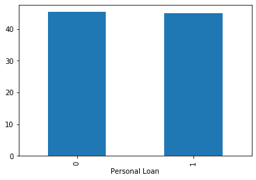

```
*** Income ***
AxesSubplot(0.125,0.125;0.775x0.755)
```

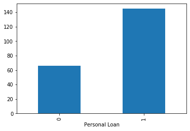

```
*** CCAvg ***
AxesSubplot(0.125,0.125;0.775x0.755)
```

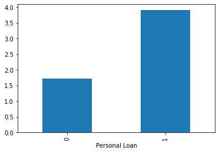

```
*** Mortgage ***
AxesSubplot(0.125,0.125;0.775x0.755)
```

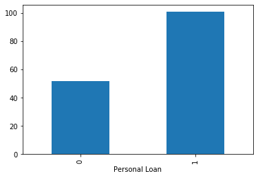

```python
for i in ['Age','Income','CCAvg','Mortgage']:
    print('***',i,'***')
    print(credit_df.groupby('Personal Loan')[i].mean().plot(kind='bar'))
    plt.show()
```

#### - Summary of Numeric Variables data analysis

- "Age " : Does not affect chances to apply for a Loan
- "Income " : People with higher income have more chances to apply for a Loan
- "Credit Card Spending CCAvg ": People with higher credit card spending have more chances to apply for a Loan
- "Mortgage ": People with higher Mortgages have more chances to apply for a Loan

### - Bivariate: Categorical Variables Vs. Target Variable

```
*** Family ***
Data:
 Personal Loan     0    1
Family
1              1365  107
2              1190  106
3               877  133
4              1088  134
Fractions:
 Personal Loan    0    1
Family
1             0.93 0.07
2             0.92 0.08
3             0.87 0.13
4             0.89 0.11
_____________________________
*** Education ***
Data:
 Personal Loan     0    1
Education
1              2003   93
2              1221  182
3              1296  205
Fractions:
 Personal Loan    0    1
Education
1             0.96 0.04
2             0.87 0.13
3             0.86 0.14
_____________________________
*** Securities Account ***
Data:
 Personal Loan          0    1
Securities Account
0                   4058  420
1                    462   60
Fractions:
 Personal Loan         0    1
Securities Account
0                  0.91 0.09
```

[output cut: 23 more lines]

```
0             0.91 0.09
1             0.90 0.10
_____________________________
*** CreditCard ***
Data:
 Personal Loan     0    1
CreditCard
0              3193  337
1              1327  143
Fractions:
 Personal Loan    0    1
CreditCard
0             0.90 0.10
1             0.90 0.10
_____________________________
```

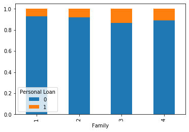

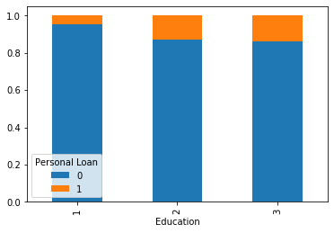

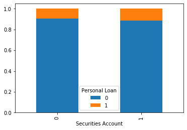

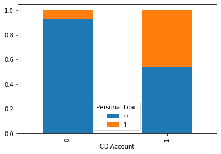

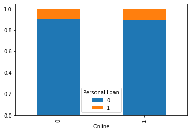

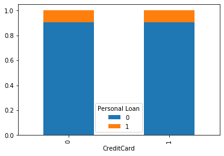

```python
for i in ['Family', 'Education','Securities Account','CD Account','Online','CreditCard']:
    aux1=pd.crosstab(credit_df[i],credit_df['Personal Loan'])
    aux1.div(aux1.sum(1).astype(float), axis=0).plot(kind='bar',stacked=True)
    print('***',i,'***')
    print('Data:',' \n',aux1," ")
    print('Fractions:',' \n',aux1.div(aux1.sum(1).astype(float),axis=0))
    print("_____________________________")
```

#### - Summary of Categorical Variables data analysis

- "Family " : Does not really affect chances to apply for a Loan
- "Education " : People with higher Education have more chances to apply for a Loan
- "Securities Account ": Does not really affect chances to apply for a Loan
- "CD Account ": People owning CD accounts have more chances to apply for a Loan
- "Online ": Does not really affect chances to apply for a Loan
- "CreditCard ": Does not really affect chances to apply for a Loan